# Ford GoBike Data Explanation

## by Oyelayo Seye

## Investigation Overview

This project has two parts that demonstrate the importance and value of data visualization techniques in the data analysis process which is a project part of the Udacity Data Analysis Nanodegree course.

In the first part I used Python visualization libraries to systematically wrangle and explore the fordgobike dataset, starting from plots of single variables and building up to plots of multiple variables.

In this second part of the project, I present the interesting relationships, patterns and insights that I discovered in the first part.

## Dataset Overview

> This data set includes information about individual rides made in a bike-sharing system covering the greater San Francisco Bay area. The dataset features data relevant to Ford's GoBike bikeshare program with regards, to date, time, distance, location, and use...

## (Visualization 1: Amount Of User Types)

> This is a graph that shows the proportion count of user type. We find that there is a large porportion of subscribers than the customers.The subscriber is about 8 times of the customer

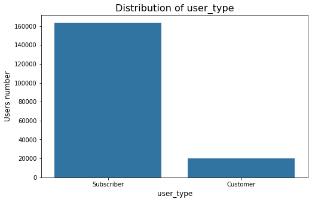

## (Visualization 1: User Types By Gender)

> The male subscribers are more than the female subscribers and the male customers are more than female customers

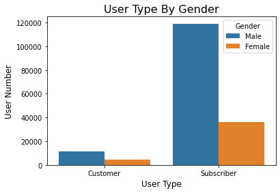

## (Visualization 2 : Trip duration (sec) per user type))

> The customers use the bikes for longer periods than subscribers, even though the subscribers are much higher in terms of numbers. By checking the two distributions, we can observe that the two have the lowest distribution, falling under 2500 secs, with customers' own higher

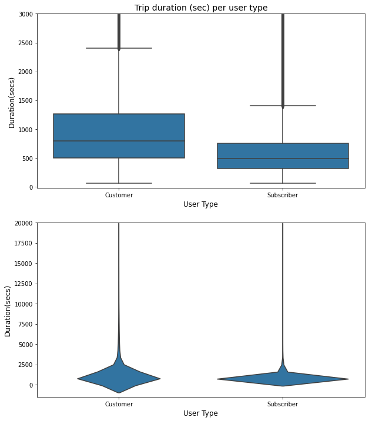

## (Visualization 3: time spent per day per 'User Type')

> Customers would use this on their non-working days as leisure, but especially at a longer time frame, as we have the highest duration seconds for Saturday and Sunday.

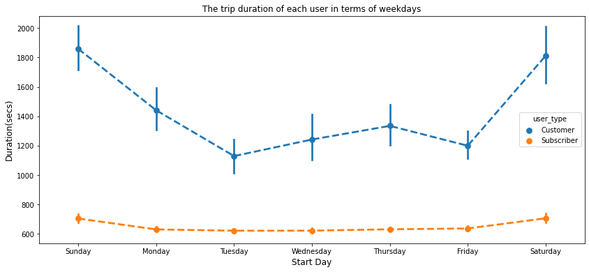

## Visualization 4: Weekly usage of the bike share system per user type

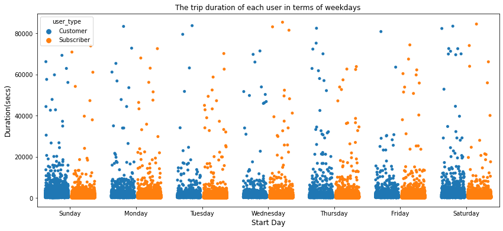